# GeoScience part 6

MSDE

Lviv University

## Spatial Data Analysis

**Exploratory Spatial Data Analysis (ESDA)**

ESDA augments **Tukey’s exploratory data analysis**: a large collection of techniques used to *“orient yourself”* — to find structure inside your dataset.

For geographical problems this usually means asking whether our data displays a **geographical pattern**.

> Whatever the nature of my data: **is there a geographical pattern**, and **are there places where this pattern does not hold?**

## Choropleth mapping

**Overview**

Choropleths are geographic maps that display statistical information encoded in a **colour palette**. They let us display non-geographic attributes on a geographic map.

The word *choropleth* stems from the root **“choro”**, meaning *region*. They represent data at the region level, and are appropriate for **areal unit data**: each observation combines a value of an attribute with a geometric figure, usually a polygon.

Choropleths derive from an era where technological constraints precluded *unclassed* maps.

## Principles

**Three dimensions to think about intentionally**

1. **How many groups?** Select a number of groups smaller than $n$ into which all values will be mapped.
2. **Which algorithm?** Identify a classification algorithm that executes the mapping following a principle aligned with our interest.
3. **Which colours?** Assign a colour to each group so it encodes the information we want to reflect.

In broad terms: the **classification scheme** defines the number of classes and the assignment rules; a good **symbolization** conveys value differentiation across classes.

> The effectiveness of a choropleth map depends largely on the **purpose** of the map.

## Choropleth mapping

```python
import seaborn
import pandas
import geopandas
import numpy
import mapclassify
import matplotlib.pyplot as plt
```

**Data classification as a problem**

Partition attribute values into **mutually exclusive and exhaustive** groups. Formally, define class boundaries such that

$$c_j < y_i \le c_{j+1} \ \forall y_i \in C_{j}$$

where $y_i$ is the value at location $i$, $j$ a class index, and $c_j$ the lower bound of interval $j$.

Different classification schemes obtain from their definition of the **class boundaries**.

## Quantitative data classification

**Example: Mexican state incomes**

Per capita GDP for 32 Mexican states, 1940:

```python
mx = geopandas.read_file(f"{GDS}/mexico/mexicojoin.shp")
mx[["NAME", "PCGDP1940"]].head()
```

|  | NAME | PCGDP1940 |
| --- | --- | --- |
| 0 | Baja California Norte | 22361.0 |
| 1 | Baja California Sur | 9573.0 |
| 2 | Nayarit | 4836.0 |
| 3 | Jalisco | 5309.0 |
| 4 | Aguascalientes | 10384.0 |

```python
ax = seaborn.histplot(mx["PCGDP1940"], bins=5)
seaborn.rugplot(
    mx["PCGDP1940"], height=0.05, color="red", ax=ax
);
```

[figure not shown]

The distribution is **positively skewed**, as is common in regional income studies: the mean exceeds the median, giving the long right tail. This skewness will have implications for the choice of scheme.

## Quantitative data classification

**The histogram is already a classifier**

```python
mx["PCGDP1940"].describe()
```

```
count       32.000000
mean      7230.531250
std       5204.952883
min       1892.000000
25%       3701.750000
50%       5256.000000
75%       8701.750000
max      22361.000000
Name: PCGDP1940, dtype: float64
```

Sort the data $x_0 \le x_1 \ldots \le x_{n-1}$. For a prespecified $k$, the problem is to select $k-1$ **break points** along the sorted values.

```python
counts, bins, patches = ax.hist(mx["PCGDP1940"], bins=5)
print(counts)
print(bins)
```

```
[17.  9.  3.  1.  2.]
[ 1892.   5985.8 10079.6 14173.4 18267.2 22361. ]
```

The first bin runs from 1892 to 5985.8 and contains 17 observations.

## Quantitative data classification

**The Freedman-Diaconis rule**

`seaborn.histplot` uses matplotlib’s `hist` under the hood to determine class boundaries. The interval width $w$ is

$$w = 2 * IQR * n^{-1/3}$$

where $IQR$ is the inter-quartile range. Given $w$, the number of bins is

$$k = \dfrac{(max-min)}{w}$$

The choropleth literature has many **alternative algorithms** that prioritize different criteria. We compute them with `mapclassify`, from the PySAL family.

## Equal intervals

**Same width in value space**

A special case of Freedman-Diaconis generalized: split the range into $k$ equal-length intervals, each of width $w = \frac{x_{n-1} - x_0}{k}$.

```python
ei5 = mapclassify.EqualInterval(mx["PCGDP1940"], k=5)
ei5
```

```
EqualInterval

      Interval         Count
----------------------------
[ 1892.00,  5985.80] |    17
( 5985.80, 10079.60] |     9
(10079.60, 14173.40] |     3
(14173.40, 18267.20] |     1
(18267.20, 22361.00] |     2
```

**Advantages and the catch**

**Dual advantages:** simplicity and ease of interpretation.

**However:** the rule only considers the *extreme values* of the distribution. In some cases this leaves one or more classes **sparse** — clearly so here, where the majority of values land in the first two classes.

## Quantiles

**Roughly equal counts**

Each class will have approximately $\mid\frac{n}{k}\mid$ observations. With $k=5$, the sample quintiles define the upper limits:

```python
q5 = mapclassify.Quantiles(mx.PCGDP1940, k=5)
q5
```

```
Quantiles

      Interval         Count
----------------------------
[ 1892.00,  3576.20] |     7
( 3576.20,  4582.80] |     6
( 4582.80,  6925.20] |     6
( 6925.20,  9473.00] |     6
( 9473.00, 22361.00] |     7
```

```python
q5.bins[1:] - q5.bins[:-1]
```

```
array([ 1006.6,  2342.4,  2547.8, 12888. ])
```

The counts are roughly equal, but the **widths of the intervals are markedly different** — which can lead to problems of interpretation.

## Quantiles

**The problem of ties**

A second challenge arises when there are **many duplicate values**, so limits for one or more classes become ambiguous.

If $n=20$ but 10 observations share the minimum value, then for $k>2$ class boundaries become ill-defined: splitting at the $n/k$ ranked value depends on how ties are treated.

```python
numpy.random.seed(12345)
# Generate a variable of 20 values randomly selected from 0 to 10
x = numpy.random.randint(0, 10, 20)
# Manually ensure the first ten values are the minimum
x[0:10] = x.min()
ties = mapclassify.Quantiles(x, k=5)
ties
```

```
Quantiles

  Interval     Count
--------------------
[0.00, 0.00] |    11
(0.00, 1.40] |     1
(1.40, 6.20] |     4
(6.20, 9.00] |     4
```

`mapclassify` warns, then forms a lower number of classes using **pseudo-quantiles** — quantiles defined on the *unique* values in the sample.

## Mean-standard deviation

**Distance from the mean, measured in $s$**

Class boundaries are set at multiples of the standard deviation from the sample mean. A common definition for $k=5$:

$$c_{0}^u = \bar{x} - 2s, \quad c_{1}^u = \bar{x}-s, \quad c_{2}^u = \bar{x}+s, \quad c_{3}^u = \bar{x}+2s$$

Values beyond $\pm 2s$ go in the top/bottom class.

```python
msd = mapclassify.StdMean(mx["PCGDP1940"])
msd
```

```
StdMean

      Interval         Count
----------------------------
(    -inf, -3179.37] |     0
(-3179.37,  2025.58] |     1
( 2025.58, 12435.48] |    28
(12435.48, 17640.44] |     0
(17640.44, 22361.00] |     3
```

Best used when data is **normally distributed**, or at least when the sample mean is a meaningful anchor. Clearly not the case here: the positive skew produces an **inadmissible upper bound** for the first class and concentrates the vast majority of values in the middle class.

## Maximum breaks

**Look at the gaps, not the values**

Rather than considering a value in itself, look at **how far apart** each value is from the next one in the sorted sequence. Place the $k-1$ break points between the pairs most stretched apart, in descending order of gap size.

```python
mb5 = mapclassify.MaximumBreaks(mx["PCGDP1940"], k=5)
mb5
```

```
MaximumBreaks

      Interval         Count
----------------------------
[ 1892.00,  5854.00] |    17
( 5854.00, 11574.00] |    11
(11574.00, 14974.00] |     1
(14974.00, 19890.50] |     1
(19890.50, 22361.00] |     2
```

**Appropriate when** we want observations in each class separated from those in neighbouring classes - works well for non-unimodal distributions, and is relatively fast.

**But** its simplicity can surprise: only the top $k-1$ differences are considered, so more nuanced within-group dissimilarities are ignored.

## Boxplot

**A blend of quantiles and standard deviation**

Here $k$ is predefined to **six**. The upper limit of the first class is

$$q_{0.25}-h \, IQR$$

and the lower limit of the sixth class is $q_{0.75}+h \, IQR$, where $h$ is the **hinge**. Intermediate classes take the 0.25, 0.50 and 0.75 percentiles.

```python
bp = mapclassify.BoxPlot(mx["PCGDP1940"])
bp
```

```
BoxPlot

      Interval         Count
----------------------------
(    -inf, -3798.25] |     0
(-3798.25,  3701.75] |     8
( 3701.75,  5256.00] |     8
( 5256.00,  8701.75] |     8
( 8701.75, 16201.75] |     5
(16201.75, 22361.00] |     3
```

Values in the extreme classes are defined as **outliers**. Since income is non-negative, the lower outlier class here has an inadmissible upper bound — lower outliers are impossible for this sample.

## Boxplot

**Changing the hinge**

The default is $h=1.5$, but it can be specified:

```python
bp1 = mapclassify.BoxPlot(mx["PCGDP1940"], hinge=1)
bp1
```

```
BoxPlot

      Interval         Count
----------------------------
(    -inf, -1298.25] |     0
(-1298.25,  3701.75] |     8
( 3701.75,  5256.00] |     8
( 5256.00,  8701.75] |     8
( 8701.75, 13701.75] |     5
(13701.75, 22361.00] |     3
```

This affects the definition of the outlier classes *and* the neighbouring internal classes.

## Head-tail breaks

**Recursive partitioning around iterative means**

Split the data around the mean, then split the “head” around *its* mean, and so on. The process continues until the distribution within each class no longer displays a **heavy tail** — there is a balance between the number of smaller and larger values.

```python
ht = mapclassify.HeadTailBreaks(mx["PCGDP1940"])
ht
```

```
HeadTailBreaks

      Interval         Count
----------------------------
[ 1892.00,  7230.53] |    20
( 7230.53, 12244.42] |     9
(12244.42, 20714.00] |     1
(20714.00, 22163.00] |     1
(22163.00, 22361.00] |     1
```

Particularly effective for data with **heavy-tailed distributions**: power law, log-normal.

## Jenks-Caspall breaks

**A heuristic, not a deterministic rule**

Aims to **minimize the sum of absolute deviations around class means**.

1. Start with a prespecified number of classes and an arbitrary initial set of breaks (e.g., quintiles)
2. Consider moving observations between *adjacent* classes — the largest value of the lowest quintile into the second, the lowest value of the second into the first
3. Make the candidate move with the largest reduction in the objective function
4. Continue until no improving moves remain

```python
numpy.random.seed(12345)
jc5 = mapclassify.JenksCaspall(mx["PCGDP1940"], k=5)
jc5
```

```
JenksCaspall

      Interval         Count
----------------------------
[ 1892.00,  2934.00] |     4
( 2934.00,  4414.00] |     9
( 4414.00,  6399.00] |     5
( 6399.00, 12132.00] |    11
(12132.00, 22361.00] |     3
```

This is the **one-dimensional case of K-Means** clustering.

## Fisher-Jenks

**Fisher-Jenks: guaranteed optimal**

A **dynamic programming** approach minimizing the sum of absolute deviations around class *medians*. Unlike Jenks-Caspall, it is guaranteed to produce an optimal classification for a prespecified $k$:

```python
numpy.random.seed(12345)
fj5 = mapclassify.FisherJenks(mx["PCGDP1940"], k=5)
fj5
```

```
FisherJenks

      Interval         Count
----------------------------
[ 1892.00,  5309.00] |    17
( 5309.00,  9073.00] |     8
( 9073.00, 12132.00] |     4
(12132.00, 17816.00] |     1
(17816.00, 22361.00] |     2
```

## Max-p

**Max-p: a region-building heuristic**

Adapts the max-p region building method to map classification. Similar in spirit to Jenks-Caspall - greedy swapping between adjacent classes - so **no optimal solution is guaranteed**:

```python
mp5 = mapclassify.MaxP(mx["PCGDP1940"], k=5)
mp5
```

```
MaxP

      Interval         Count
----------------------------
[ 1892.00,  3569.00] |     7
( 3569.00,  5309.00] |    10
( 5309.00,  7990.00] |     5
( 7990.00,  9573.00] |     4
( 9573.00, 22361.00] |     6
```

## Comparing classification schemes

**Optimality is relative to an objective**

Freedman-Diaconis is “optimal” - but only relative to *its* objective function: minimizing the difference between the area under the estimated kernel density and that under the theoretical population distribution.

This notion of **statistical fit** is important, but it is not the only consideration. Also relevant:

- the **spatial** distribution of the attribute values
- the ability of the classifier to convey a sense of that spatial distribution

And these are *not necessarily* directly related to the statistical distribution.

## Comparing classification schemes

**Absolute deviation around class medians (ADCM)**

A measure of fit allowing comparison of alternative classifiers for the same $k$ — a sense of how “compact” each group is. **Lower is better.**

```python
# Bunch classifier objects
class5 = q5, ei5, ht, mb5, msd, fj5, jc5, mp5
# Collect ADCM for each classifier
fits = numpy.array([c.adcm for c in class5])
adcms = pandas.DataFrame(fits)
adcms["classifier"] = [c.name for c in class5]
adcms.columns = ["ADCM", "Classifier"]
ax = seaborn.barplot(
    y="Classifier", x="ADCM", data=adcms, hue="Classifier",
    palette="Pastel1", legend=False
)
```

[figure not shown]

**Reading the ADCM chart**

As expected, **Fisher-Jenks dominates** all other $k=5$ classifiers, with an ADCM of 23,729.

Interestingly, **equal interval performs well** despite its sensitivity to extreme values.

The **mean-standard deviation classifier has a very poor fit**, due to the skewed nature of the data and the concentrated assignment of the majority of observations to the central class.

## Comparing classification schemes

**Per-observation comparison**

The ADCM is a *global* measure. As a complement, consider how each observation was classified across the alternatives, using the class bin attribute `yb`:

```python
mx["Quantiles"] = q5.yb
mx["Equal Interval"] = ei5.yb
mx["Head-Tail Breaks"] = ht.yb
mx["Maximum Breaks"] = mb5.yb
mx["Mean-Standard Deviation"] = msd.yb
mx["Fisher-Jenks"] = fj5.yb
mx["Jenks Caspall"] = jc5.yb
mx["MaxP"] = mp5.yb
```

We sort rows by value and transpose (`.T`) so states run along the horizontal axis and schemes along the vertical.

## Comparing classification schemes

```python
f, ax = plt.subplots(1, figsize=(9, 3))
seaborn.heatmap(
    mx.set_index("NAME")
    .sort_values("PCGDP1940")[
        [
            "Head-Tail Breaks",
            "Fisher-Jenks",
            "Maximum Breaks",
            "Equal Interval",
            "MaxP",
            "Quantiles",
            "Jenks Caspall",
            "Mean-Standard Deviation",
        ]
    ]
    .T,
    cmap="YlGn",
    cbar=False,
    ax=ax,
)
ax.set_xlabel("State ID");
```

[figure not shown]

Each **row** is a full series classified by one algorithm (light yellow = lowest group, dark green = largest). Each **column** is how one state fares across schemes.

## Comparing classification schemes

**What the heatmap reveals**

- The only state treated **consistently** across all $k=5$ classifiers is **Baja California Norte**, placed in the highest class by every one
- The mean-standard deviation classifier has an **empty first class**, due to the inadmissible upper bound and over-concentration in the central class

A meso-level view — counts per class per classifier:

```python
pandas.DataFrame(
    {c.name: c.counts for c in class5},
    index=["Class-{}".format(i) for i in range(5)],
)
```

|  | Quantiles | EqualInterval | HeadTailBreaks | MaximumBreaks | StdMean | FisherJenks | JenksCaspall | MaxP |
| --- | --- | --- | --- | --- | --- | --- | --- | --- |
| Class-0 | 7 | 17 | 20 | 17 | 0 | 17 | 4 | 7 |
| Class-1 | 6 | 9 | 9 | 11 | 1 | 8 | 9 | 10 |
| Class-2 | 6 | 3 | 1 | 1 | 28 | 4 | 5 | 5 |
| Class-3 | 6 | 1 | 1 | 1 | 0 | 1 | 11 | 4 |
| Class-4 | 7 | 2 | 1 | 2 | 3 | 2 | 3 | 6 |

Fisher-Jenks and equal intervals are strikingly similar — they agree on all 17 states in the first class. The only state distinguishing them is **Baja California Sur**.

## Color

**A caution before we colour**

The spatial units are far from **homogeneous in shape and size**. This has major impacts on our brain’s pattern recognition: we are drawn to the **larger polygons**, even when they are not the most relevant.

Yet when we considered the *statistical* distribution above, each observation was given **equal weight**.

Thus the spatial distribution is more complicated to evaluate, from both a visual and a statistical perspective.

## Color

**Three types of numerical attribute**

The choice of colour scheme should be based on the type of variable:

- **sequential** — continuous data with the origin at one end of the series
- **diverging** — continuous data with a meaningful mid-range critical value
- **qualitative** — categorical data

## Sequential palettes

**Making a choropleth**

Making choropleths on geo-tables is an extension of plotting their geometries — the same `.plot()` function, plus the column to encode with colour.

```python
ax = mx.plot(
    column="PCGDP1940",  # Data to plot
    scheme="Quantiles",  # Classification scheme
    cmap="YlGn",  # Color palette
    legend=True,  # Add legend
    legend_kwds={"fmt": "{:.0f}"},  # Remove decimals in legend
)
ax.set_axis_off();
```

[figure not shown]

The classification scheme uses the same names as `mapclassify` — in fact the underlying computation *is* `mapclassify`, just dispatched so we can make maps in one line.

## Sequential palettes

**A gradient from an origin to a destination colour**

Sequential palettes can also use shades of a single colour:

```python
ax = mx.plot(
    column="PCGDP1940",
    scheme="Quantiles",
    cmap="Blues",  # Color palette
    edgecolor="k",  # Borderline color
    linewidth=0.1,  # Borderline width
    legend=True,
    legend_kwds={"fmt": "{:.0f}"},
)
ax.set_axis_off();
```

[figure not shown]

Note we switch borderlines to **black** so states in the lowest category can be distinguished from the white background.

## Diverging palettes

**Equal emphasis on the middle *and* both extremes**

Light colours emphasize the mid-range class; dark colours with **contrasting hues** distinguish low and high extremes.

To illustrate, derive the change in a state’s *rank* in the income distribution from 1940 to 2000:

```python
# Create income-based rank table (Rank 1 is highest)
rnk = mx[["NAME", "PCGDP1940", "PCGDP2000"]].rank(ascending=False)
# Compute change from 1940 to 2000
rnk["change"] = rnk["PCGDP1940"] - rnk["PCGDP2000"]
# Add column with bin class
rnk["class"] = pandas.cut(
    rnk["change"], [-numpy.inf, -5, 0, 5, 20]
)
```

These are **descending** ranks: the wealthiest state has rank 1, so a negative change means moving *down* the income distribution.

```python
ax = (
    mx[["geometry"]]
    .join(rnk)
    .plot("class", legend=True, cmap="RdYlGn")
)
ax.set_axis_off();
```

[figure not shown]

Red hues are states that moved **downward** in the income distribution, green hues **upward**; darker hues represent a larger movement.

## Qualitative palettes

**Categorical data: differences, not magnitudes**

Colours do **not** follow a gradient — observations in one group are not more or less, above or below others, just *different*.

The Mexico data has a region definition grouping states into contiguous clusters:

```python
mx["HANSON98"].head()
```

```
0    1.0
1    2.0
2    2.0
3    3.0
4    2.0
Name: HANSON98, dtype: float64
```

A naive and **incorrect** display treats region as sequential:

```python
ax = mx.plot("HANSON98")
ax.set_axis_off();
```

[figure not shown]

## Qualitative palettes

**Why that map is wrong**

The region variable is **not on an interval scale**. Differences between values have no quantitative significance — they simply indicate region membership.

Yet the choropleth gives a clear visual cue that regions in the south have *larger values* than those in the north, because the colour map implies an intensity gradient.

**The fix:** declare the variable categorical.

```python
ax = mx.plot("HANSON98", categorical=True, legend=True)
ax.set_axis_off();
```

[figure not shown]

## User-defined choropleths

**When domain knowledge sets the breaks**

Bespoke partitions that follow no algorithm but are informed by, e.g., policy. Imagine exploring areas below $$$10,000; between $$$10,000 and $$$12,500; $$$12,500 and $$$15,000; and above $$$15,000 — where the first group is targeted one way, the second and third differently, and the fourth is outside the policy.

```python
classi = mapclassify.UserDefined(
    mx["PCGDP2000"], [10000, 12500, 15000]
)
classi
```

```
UserDefined

      Interval         Count
----------------------------
[ 8684.00, 10000.00] |     2
(10000.00, 12500.00] |     7
(12500.00, 15000.00] |     1
(15000.00, 54349.00] |    22
```

## User-defined choropleths

**`mapclassify`’s own plotting method**

```python
classi.plot(
    mx,  # Use geometries in the geo-table
    legend=True,
    legend_kwds={"loc": "upper right"},
    axis_on=False,  # Remove axis
    cmap="viridis_r",  # Use reverse Viridis
);
```

[figure not shown]

We use **reverse viridis** to draw attention to the classes at the *bottom* of the scale — purple areas are those *not* targeted by our hypothetical policy.

## User-defined choropleths

**The `pandas` alternative**

`pandas.cut` gives an easy legend too:

```python
# Classify values specifying bins
lbls = pandas.cut(
    mx["PCGDP2000"], [-numpy.inf, 10000, 12500, 15000, numpy.inf]
)
# Dynamically assign to geo-table and plot with a legend
ax = mx.plot(lbls, cmap="viridis_r", legend=True)
ax.set_axis_off();
```

[figure not shown]

## Pooled classifications

**One classification *across* several maps**

Sometimes a choropleth is part of a larger figure with more choropleths. If each is an independent map, everything above applies directly. But often we want a **single classification used consistently** across the series.

```python
# List the years we want of pc GDP
years = ["PCGDP1940", "PCGDP1960", "PCGDP1980", "PCGDP2000"]
# Create pooled classification
pooled = mapclassify.Pooled(
    mx[years].values, classifier="Quantiles", k=5
)
pooled.global_classifier.bins
```

```
array([ 6399. ,  9664.2, 13941.6, 21509.2, 54349. ])
```

We then feed the **global bins** to `UserDefined` on each panel.

```python
f, axs = plt.subplots(2, 2, figsize=(9, 9))
axs = axs.flatten()
for i, y in enumerate(years):
    mx.plot(
        y,  # Year to plot
        scheme="UserDefined",  # Use our own bins
        classification_kwds={
            "bins": pooled.global_classifier.bins
        },  # Use global bins
        legend=True,
        ax=axs[i],
    )
    axs[i].set_axis_off()
    axs[i].set_title(y)
plt.tight_layout()
plt.show()
```

[figure not shown]

# Global Spatial Autocorrelation

## Global spatial autocorrelation

**The concept**

> The existence of a “functional relationship between what happens at one point in space and what happens elsewhere” - Anselin (1988)

The degree to which **similarity in values** between observations is related to **similarity in locations**.

Compare with its relatives:

- **correlation** — how values in one variable change as a function of another
- **temporal autocorrelation** — the value of a variable now, vs. previous periods
- **spatial autocorrelation** — the value of a variable *here*, vs. the same variable *elsewhere*

## Global spatial autocorrelation

**An alternative framing**

The degree of **information contained** in the value of a variable at a given location **about the value of that same variable in other locations**.

**Start from its absence**

**Spatial randomness**: a situation in which the location of an observation gives *no information whatsoever* about its value. A variable is spatially random if its distribution follows no discernible spatial pattern.

> Spatial autocorrelation is the **absence of spatial randomness**.

## Spatial autocorrelation

**Two dimensions: sign and scale**

**Sign**:

- *positive* (similarity and geographical closeness go hand in hand)
- *negative* (similar values located away from each other).

**Scale**:

- *global* (the overall trend that the location of values follows; the degree of **clustering**)
- *local* (deviations from the global trend at much more focused levels).

## Example: the EU Referendum

```python
# Graphics
import matplotlib.pyplot as plt
import seaborn
import splot
from splot.esda import plot_moran
import contextily

# Analysis
import geopandas
import pandas
import esda
from libpysal import weights
from numpy.random import seed
```

**The data**

The 2016 **Brexit** referendum, official Electoral Commission data at the local authority level:

- **Electoral Commission** — vote percentages at local authority level (`csv`)
- **ONS** — Local Authority Districts (December 2016) Generalised Clipped Boundaries, WGS84 (GeoJSON)

Our variable of interest is `Pct_Leave`: the proportion of votes for the Leave campaign.

## EU Referendum

**Reading and joining**

```python
ref = pandas.read_csv(
    f"{GDS}/brexit/brexit_vote.csv", index_col="Area_Code"
)
lads = geopandas.read_file(
    f"{GDS}/brexit/local_authority_districts.geojson"
).set_index("lad16cd")

db = (
    geopandas.GeoDataFrame(
        lads.join(ref[["Pct_Leave"]]), crs=lads.crs
    )
    .to_crs(epsg=3857)[
        ["objectid", "lad16nm", "Pct_Leave", "geometry"]
    ]
    .dropna()
)
db.info()
```

```
<class 'geopandas.geodataframe.GeoDataFrame'>
Index: 380 entries, E06000001 to W06000023
Data columns (total 4 columns):
 #   Column     Non-Null Count  Dtype
---  ------     --------------  -----
 0   objectid   380 non-null    int32
 1   lad16nm    380 non-null    str
 2   Pct_Leave  380 non-null    float64
 3   geometry   380 non-null    geometry
dtypes: float64(1), geometry(1), int32(1), str(1)
memory usage: 20.9 KB
```

We project to **Spherical Mercator** (EPSG:3857), the preferred choice of web maps, so we can combine with contextual tiles.

## EU Referendum

```python
f, ax = plt.subplots(1, figsize=(8, 8))
db.plot(
    column="Pct_Leave",
    cmap="viridis",
    scheme="quantiles",
    k=5,
    edgecolor="white",
    linewidth=0.0,
    alpha=0.75,
    legend=True,
    legend_kwds={"loc": 2},
    ax=ax,
)
contextily.add_basemap(
    ax, crs=db.crs, source=contextily.providers.Esri.WorldTerrain
)
ax.set_axis_off()
```

[figure not shown]

Percentage of voters wanting to leave the EU in the 2016 UK Referendum.

## EU Referendum

**The spatial weights**

```python
# Generate W from the GeoDataFrame
w = weights.KNN.from_dataframe(db, k=8)
# Row-standardization
w.transform = "R"
```

Eight nearest neighbours, **row-standardized**.

## EU Referendum

**Why we need statistics at all**

At first sight, the map appears to display a fair amount of positive spatial autocorrelation. But **humans are very good pattern detectors** — life has rewarded pattern recognition since we started as a species.

This extraordinary capability also creates many **false positives**. And on maps, the shape and size of geometries further distort our perception.

We can *guess* at the presence of spatial autocorrelation. Determining whether what we see could have come from pure chance is easier said than done.

## The spatial lag

**Definition**

One of the most common and direct applications of spatial weights. In matrix notation:

$$Y_{sl} = \textbf{W} Y$$

or, individually:

$$y_{sl-i} = \sum_j w_{ij} y_j$$

Because non-neighbours receive a weight of zero, $y_{sl-i}$ really captures the product of values and weights for $i$’s **neighbours**.

- if $\textbf{W}$ is **binary** $\rightarrow$ the *sum* of the values of $i$’s neighbours
- if $\textbf{W}$ is **row-standardized** $\rightarrow$ a **local average**: the average value of $Y$ in the neighbourhood of $i$

Conceptually, the spatial lag captures the behaviour of a variable in the immediate surroundings of each location - it is akin to a **local smoother**.

## The spatial lag

**Two local authorities**

```python
db["Pct_Leave_lag"] = weights.spatial_lag.lag_spatial(
    w, db["Pct_Leave"]
)
db.loc[["E08000012", "S12000019"], ["Pct_Leave", "Pct_Leave_lag"]]
```

| lad16cd | Pct_Leave | Pct_Leave_lag |
| --- | --- | --- |
| E08000012 | 41.81 | 54.61375 |
| S12000019 | 37.94 | 38.01875 |

- `E08000012` is **Liverpool** — a notorious “Remainer” island among the mostly-Leave North of England
- `S12000019` is **Midlothian**, in Scotland, where no local authority voted to leave

Both display a *similar* percentage voting to leave (42% and 38%). But the difference in their **spatial lags** captures the wider geographical context, which is quite different.

```python
f, axs = plt.subplots(1, 2, figsize=(11, 5.5))
ax1, ax2 = axs
for col, ax, title in [
    ("Pct_Leave", ax1, "% Leave"),
    ("Pct_Leave_lag", ax2, "% Leave - Spatial Lag"),
]:
    db.plot(
        column=col,
        cmap="viridis",
        scheme="quantiles",
        k=5,
        edgecolor="white",
        linewidth=0.0,
        alpha=0.75,
        legend=True,
        ax=ax,
    )
    ax.set_axis_off()
    ax.set_title(title)
    contextily.add_basemap(
        ax,
        crs=db.crs,
        source=contextily.providers.Esri.WorldTerrain,
    )
plt.show()
```

[figure not shown]

Stark differences between immediate neighbours on the left (Liverpool!) are **diminished** on the right: the lag smooths.

## Binary case: join counts

**The checkerboard intuition**

Imagine a checkerboard with green (G, value 0) and yellow (Y, value 1) squares. Count the occurrences of:

- **GG** and **YY** joins → positive spatial autocorrelation
- **GY / YG** joins → negative spatial autocorrelation

Compare the **observed** counts with a **baseline** of how many one would expect under complete spatial randomness.

```python
db["Leave"] = (db["Pct_Leave"] > 50).astype(int)
db[["Pct_Leave", "Leave"]].tail(3)
```

| lad16cd | Pct_Leave | Leave |
| --- | --- | --- |
| W06000021 | 49.56 | 0 |
| W06000022 | 55.99 | 1 |
| W06000023 | 53.74 | 1 |

```python
f, ax = plt.subplots(1, figsize=(7, 7))
db.plot(
    ax=ax,
    column="Leave",
    categorical=True,
    legend=True,
    edgecolor="0.5",
    linewidth=0.25,
    cmap="Set3",
)
ax.set_axis_off()
ax.set_title("Leave Majority")
plt.axis("equal")
plt.show()
```

[figure not shown]

Visually, a clear case of positive spatial autocorrelation: few visible cases of an observation surrounded by others in the opposite category.

## Binary case: join counts

**A note on the naming**

The checkerboard above is green and yellow; `esda` calls the two categories **black** and **white**. So the three counts are:

| `esda` | here | meaning |
| --- | --- | --- |
| `bb` | GG | both neighbours are **1** (Leave majority) |
| `ww` | YY | both neighbours are **0** (Remain majority) |
| `bw` | GY | the two neighbours **differ** |

`bb` and `ww` are the *same-category* joins; `bw` is the *opposite* join.

## Binary case: join counts

**Computing the statistic**

Since weights here only delimit *who is a neighbour*, the join count statistic requires **binary** weights — transform `w` back to its original state:

```python
w.transform = "O"
seed(1234)
jc = esda.join_counts.Join_Counts(db["Leave"], w)
print("BB (Leave-Leave):    ", jc.bb)
print("WW (Remain-Remain):  ", jc.ww)
print("BW (opposite):       ", jc.bw)
print("Total joins J:       ", jc.J)
```

```
BB (Leave-Leave):     871.0
WW (Remain-Remain):   302.0
BW (opposite):        347.0
Total joins J:        1520.0
```

## Every join is counted once

**The three classes partition the joins**

Each neighbour pair falls into exactly one of the three classes, so they must sum to the total number of joins:

$$\text{bb} + \text{ww} + \text{bw} = J$$

```python
print("bb + ww + bw =", jc.bb + jc.ww + jc.bw)
print("J            =", jc.J)
print("equal        :", jc.bb + jc.ww + jc.bw == jc.J)
```

```
bb + ww + bw = 1520.0
J            = 1520.0
equal        : True
```

$J$ is a property of the **weights matrix alone** — it is the number of neighbour pairs in the graph, and it does not change when you relabel the observations. Only the *split* between the three classes carries information about the map.

That is exactly why the permutation test works: shuffling `Leave` across the districts redistributes joins between `bb`, `ww` and `bw` while leaving $J$ fixed.

**And there is more in the object**

```python
print([a for a in dir(jc) if not a.startswith("_")])
```

[output not shown]

As is common in PySAL, `jc` holds far more than the statistic itself — simulated minima and maxima, a $\chi^2$ test, the crosstabulation, and directional autocorrelation results.

## Binary case: join counts

**Observed vs. expected**

The statistic compares the **observed** counts against what complete spatial randomness would produce. `esda` estimates the expectation by simulation:

```python
pandas.DataFrame(
    {
        "observed": [jc.bb, jc.bw],
        "expected": [round(jc.mean_bb, 1), round(jc.mean_bw, 1)],
        "pseudo p": [jc.p_sim_bb, jc.p_sim_bw],
    },
    index=["bb (same category)", "bw (opposite)"],
)
```

|  | observed | expected | pseudo p |
| --- | --- | --- | --- |
| bb (same category) | 871.0 | 727.4 | 0.001 |
| bw (opposite) | 347.0 | 649.3 | 1.000 |

Read both rows together, because that is what identifies the *direction*:

- same-category joins are **above** expectation — 871 against 727
- opposite joins are **far below** it — 347 against 649, barely half

More same and fewer opposite is the signature of **positive** spatial autocorrelation. The reverse — more `bw` than expected — would indicate a checkerboard, i.e. negative autocorrelation.

**Interpreting `p_sim`**

An **empirical p-value**: the proportion of realizations in the simulation under spatial randomness that are more extreme than the observed value.

A small enough p-value lets us **reject the hypothesis that the map is random** — the map displays more spatial pattern than we would expect if values had been randomly allocated to locations.

`0.001` is actually the **minimum value obtainable** given 999 permutations.

Nearby areas tended to vote alike.

## Reading the pseudo $p$-values

**Both are one-sided, and one of them looks alarming**

Inference uses **999 random spatial permutations** of the observed values, building synthetic maps under the null of complete spatial randomness and counting how often the simulated statistic is at least as large as the observed one.

Both $p$-values are **one-sided**, with the alternative *“observed is greater than under randomness”*:

- $p_{bb} = 0.001$ — essentially no permutation produced this many same-category joins. Strong evidence.
- $p_{bw} = 1.0$ — **this is not a failed test.** It means the observed number of opposite joins was *lower than every single simulation*. Under a one-sided “greater than” alternative that is the most extreme possible result in the **opposite** direction, and it reinforces the conclusion rather than contradicting it.

A $p$-value of exactly 1.0 from a one-sided permutation test is informative, not a bug. If you want a two-sided statement about `bw`, test the other tail.

**Where the statistic comes from**

Join counts are among the oldest spatial-autocorrelation statistics, formalised in **Cliff & Ord**, *Spatial Processes: Models and Applications*, Pion, 1981. They apply only to **binary** data — which is why the next section moves to Moran’s $I$ for the continuous case.

## Continuous case: Moran’s $I$

**The statistic**

$$I = \dfrac{n}{\sum_i\sum_j w_{ij}} \dfrac{\sum_i\sum_j w_{ij} \, z_i \, z_j}{\sum_i z_i^2}$$

where $n$ is the number of observations, $z_i$ the standardized value at $i$, and $w_{ij}$ the cell of $W$ for the pair $(i,j)$.

## What is $z_i$?

**“Standardized” means centred on the mean**

$$z_i = y_i - \bar{y}$$

Each observation expressed as a **departure from the average**, so positive means above average and negative means below. Some texts use the full $z$-score, $(y_i - \bar{y})/\sigma$, and divide by the standard deviation as well.

**For Moran’s $I$ it makes no difference which you use.** Look at where $z$ appears in the formula: quadratically, in both the numerator ($z_i z_j$) and the denominator ($\sum_i z_i^2$). Multiply every $z$ by a constant $c$ and both scale by $c^2$, which cancels.

## Continuous case: Moran’s $I$

```python
db["Pct_Leave_std"] = db["Pct_Leave"] - db["Pct_Leave"].mean()
db["Pct_Leave_lag_std"] = weights.lag_spatial(
    w, db["Pct_Leave_std"]
)
```

```python
f, ax = plt.subplots(1, figsize=(5.5, 5.5))
seaborn.regplot(
    x="Pct_Leave_std",
    y="Pct_Leave_lag_std",
    ci=None,
    data=db,
    line_kws={"color": "r"},
)
ax.axvline(0, c="k", alpha=0.5)
ax.axhline(0, c="k", alpha=0.5)
ax.set_title("Moran Plot - % Leave")
plt.show()
```

[figure not shown]

**Reading the Moran Plot**

The horizontal axis is the standardized Leave percentage; the vertical is its spatial lag which, because $W$ is row-standardized, is the **average standardized Leave vote in the neighbourhood** of each observation.

The **linear fit** represents the best way to summarize the relationship as a straight line — and it is **positive**.

> Local authorities where people voted in high proportion to leave the EU tend to be located nearby other regions that also registered high Leave proportions.

This does not mean there are *no* high-among-low cases. It means that, if we had to summarize the main pattern, it is positive clustering over space.

## Continuous case: Moran’s $I$

**From picture to number**

Just as the **mean** summarizes a histogram in a non-spatial setting, **Moran’s $I$** summarizes the Moran Plot.

In fact there is a close connection: **the value of Moran’s $I$ is the slope of the linear fit** overlaid on the Moran Plot.

```python
w.transform = "R"
moran = esda.moran.Moran(db["Pct_Leave"], w)
print("Moran's I:", round(moran.I, 4))
print("p_sim:    ", moran.p_sim)
```

```
Moran's I: 0.6455
p_sim:     0.001
```

## Continuous case: Moran’s $I$

```python
plot_moran(moran);
```

[figure not shown]

**Left:** the empirical distribution from 999 random maps (grey), the mean (blue rug), and the observed Moran’s $I$ (red rug) — clearly far to the right.

**Right:** the equivalent Moran scatterplot.

## Other global indices

**The contiguity ratio: Geary’s $C$**

$$C = \dfrac{(n-1)}
{2 \sum_i \sum_j w_{ij}}
\dfrac{\sum_i \sum_j w_{ij} (y_i - y_{j})^2}
{\sum_i (y_i - \bar{y})^2}$$

Both Moran and Geary compare the relationship of $Y$ within each observation’s local neighbourhood to that over the entire sample. But:

- Moran’s $I$ takes **cross-products on standardized values**
- Geary’s $C$ uses **differences on the raw values**, without standardization

Geary’s $C$ is computationally more demanding.

```python
geary = esda.geary.Geary(db["Pct_Leave"], w)
print("Geary's C:", round(geary.C, 4), "| p_sim:", geary.p_sim)
```

```
Geary's C: 0.408 | p_sim: 0.001
```

Geary’s $C$ points in the same direction as Moran’s $I$: clear spatial autocorrelation.

## Other global indices

**A statistic of concentration: Getis and Ord’s $G$**

$$G(d) = \dfrac{ \sum_i \sum_j w_{ij}(d) \, y_i \, y_j }
{ \sum_i \sum_j y_i \, y_j }$$

where $w_{ij}(d)$ is a **binary distance band** weight.

Conceived for **points** (hence a distance $W$), but applicable to polygons given a binary weights matrix. Designed for **positive variables with a natural origin**.

**An important limitation**

$G$ was proposed as a measure of **concentration** rather than of spatial autocorrelation. It is well suited to testing to what extent similar values - high *or* low - tend to co-locate.

It is a statistic of *positive* spatial autocorrelation only: because $G$ measures the intensity with which $Y$ is concentrated, **it cannot pick up negative spatial autocorrelation**.

## Other global indices

**Building a distance band for Getis and Ord’s $G$**

To make sure every observation has at least one neighbour, use `min_threshold_distance`, projecting to the Ordnance Survey CRS (EPSG:27700), expressed in metres:

```python
db_osgb = db.to_crs(epsg=27700)
pts = db_osgb.centroid
xys = pandas.DataFrame({"X": pts.x, "Y": pts.y})
min_thr = weights.util.min_threshold_distance(xys)
min_thr
```

```
np.float64(180878.91800926375)
```

For every local authority to have a neighbour, the distance band needs to be at least **about 181 km**.

```python
w_db = weights.DistanceBand.from_dataframe(db_osgb, min_thr)
gao = esda.getisord.G(db["Pct_Leave"], w_db)
print(
    "Getis & Ord G: %.3f | Pseudo P-value: %.3f"
    % (gao.G, gao.p_sim)
)
```

```
Getis & Ord G: 0.434 | Pseudo P-value: 0.003
```

A clear departure from the hypothesis of no concentration.

## Global spatial autocorrelation

**Take-aways**

Global measures of spatial autocorrelation **leverage statistics** to do two things:

1. **summarize** the spatial distribution of values present in a map
2. obtain a **formal quantification of the departure from randomness**

| Statistic | Built on | Detects |
| --- | --- | --- |
| Join counts | same/opposite category pairs | positive & negative (binary data) |
| Moran’s $I$ | cross-products of standardized values | positive & negative |
| Geary’s $C$ | squared differences of raw values | positive & negative |
| Getis-Ord $G$ | products under a distance band | **positive only** (concentration) |

All of them are “whole map” statistics: **a single summary for the entire dataset**.

# Local Spatial Autocorrelation

## Local spatial autocorrelation

**Why global is not enough**

Global measures are **“whole map” statistics**: a single summary for an entire dataset.

Moran’s $I$ tells us whether values in our map *cluster* together (or disperse) overall — but it will **not** tell us *where* specific clusters or outliers are.

**Local** measures focus on the relationship between *each* observation and its surroundings. They are not summary statistics but **scores** that let us learn more about the spatial structure in our data.

## Local spatial autocorrelation

**Where spatial autocorrelation comes from**

- **Spillovers** - outcomes at one site *influence* other sites
- **Contagion** - outcomes at one site *causally influence* other sites
- **Heterogeneity** - systematic spatial variation
- **Measurement artifacts** - e.g., “down-sampling” can create large patches of identical values

Substantive or nuisance, it is a form of **non-randomness** that complicates statistical analysis.

**LISAs**

**Local Indicators of Spatial Association** (Anselin, 1995). Some local statistics are mathematically connected to their global counterparts: the global version can be **decomposed into a collection of local ones**.

## An empirical illustration

```python
from matplotlib import colors
import rioxarray  # Surface data manipulation
import xarray  # Surface data manipulation
```

**Same data, same weights**

We continue with the Brexit dataset and the same 8-nearest-neighbour, row-standardized weights.

```python
w = weights.distance.KNN.from_dataframe(db, k=8)
w.transform = "R"
```

## Local spatial autocorrelation

**Back to the Moran Plot**

```python
db["w_Pct_Leave"] = weights.lag_spatial(w, db["Pct_Leave"])
db["Pct_Leave_std"] = db["Pct_Leave"] - db["Pct_Leave"].mean()
db["w_Pct_Leave_std"] = weights.lag_spatial(
    w, db["Pct_Leave_std"]
)
```

Standardized values divide each variable into two groups: **above-average** (positive) and **below-average** (negative). Applied to *both* the variable and its lag, this divides the Moran scatterplot into **four quadrants**.

```python
f, ax = plt.subplots(1, figsize=(5.5, 5.5))
seaborn.regplot(
    x="Pct_Leave_std", y="w_Pct_Leave_std", data=db, ci=None
)
plt.axvline(0, c="k", alpha=0.5)
plt.axhline(0, c="k", alpha=0.5)
plt.text(20, 5, "HH", fontsize=25, c="r")
plt.text(12, -11, "HL", fontsize=25, c="r")
plt.text(-20, 8.0, "LH", fontsize=25, c="r")
plt.text(-25, -11.0, "LL", fontsize=25, c="r")
plt.show()
```

[figure not shown]

**HH** top-right, **LH** top-left, **LL** bottom-left, **HL** bottom-right.

## Local Moran’s $I_i$

**The statistic**

$$I_i = \dfrac{z_i}{m_2} \displaystyle\sum_j w_{ij} z_j \; ; \; m_2 = \dfrac{\sum_i z_i^2}{n}$$

where $m_2$ is the second moment (variance) of the distribution, $z_i = y_i - \bar{y}$, and $w_{ij}$ the spatial weight for the pair $(i,j)$.

The mechanism is similar to the global Moran’s $I$, but applied **to each observation** - giving as many statistics as original observations.

**What it identifies**

Cases in which the value of an observation and the average of its surroundings are either **more similar** (HH, LL) or **more dissimilar** (HL, LH) than we would expect from pure chance.

The quadrant classification alone is *exhaustive* — every point gets a label. LISAs add the crucial question: **is the concentration unusually strong?**

## Local Moran’s $I_i$

**Computing and inspecting**

```python
lisa = esda.moran.Moran_Local(db["Pct_Leave"], w)
```

```python
ax = seaborn.kdeplot(lisa.Is)
seaborn.rugplot(lisa.Is, ax=ax);
```

[figure not shown]

A rather **skewed** distribution, due to the dominance of positive forms of spatial association. High positive values arise from value similarity - high-next-to-high **or** low-next-to-low. **The $I_i$ values alone cannot distinguish these two cases.**

The left tail represents negative spatial association - again in two forms (HL and LH) that $I_i$ cannot tell apart.

## Local Moran’s $I_i$

**Why a choropleth of $I_i$ is not enough**

A map of the raw $I_i$ values tells us whether local association is positive (HH/LL) or negative (HL/LH), but it **cannot** tell us whether the yellow areas in Scotland are similar to the yellow cluster in the east.

Are they both HH? Both LL? One of each?

And: values around zero are not statistically significant. **Which local statistics are clusters, and which are mere noise?**

**Four maps, four acts**

1. a plain choropleth of the local statistic $I_i$
2. the **quadrant** each area falls into
3. whether the statistic is **significant**
4. the combination of 2 and 3 — the **cluster map**

`splot` provides a lightweight visualization layer for exactly this.

## Local Moran’s $I_i$

```python
from splot import esda as esdaplot

f, axs = plt.subplots(nrows=2, ncols=2, figsize=(10, 10))
axs = axs.flatten()

# 1. Choropleth of local statistics
db.assign(Is=lisa.Is).plot(
    column="Is",
    cmap="plasma",
    scheme="quantiles",
    k=5,
    edgecolor="white",
    linewidth=0.1,
    alpha=0.75,
    legend=True,
    ax=axs[0],
)

# 2. Quadrant categories (p=1 so every polygon gets a colour)
esdaplot.lisa_cluster(lisa, db, p=1, ax=axs[1])

# 3. Significance map
labels = pandas.Series(
    1 * (lisa.p_sim < 0.05), index=db.index
).map({1: "Significant", 0: "Non-Significant"})
db.assign(cl=labels).plot(
    column="cl",
    categorical=True,
    k=2,
    cmap="Paired",
    linewidth=0.1,
    edgecolor="white",
    legend=True,
    ax=axs[2],
)

# 4. Cluster map at the 5% level
esdaplot.lisa_cluster(lisa, db, p=0.05, ax=axs[3])

for i, ax in enumerate(axs.flatten()):
    ax.set_axis_off()
    ax.set_title(
        [
            "Local Statistics",
            "Scatterplot Quadrant",
            "Statistical Significance",
            "Moran Cluster Map",
        ][i],
        y=0,
    )
f.tight_layout()
plt.show()
```

[figure not shown]

## Local Moran’s $I_i$

**The quadrant attribute**

```python
lisa.q[:10]
```

```
array([1, 1, 1, 1, 1, 1, 4, 1, 4, 1])
```

`1` = **HH**, `2` = **LH**, `3` = **LL**, `4` = **HL**.

```python
pandas.Series(lisa.q).value_counts()
```

```
1    183
3    113
2     50
4     34
Name: count, dtype: int64
```

High-high (1) and low-low (3) predominate.

Comparing the top two maps reveals that the positive local association in **Scotland** is due to *low* support for Brexit, while in the **south** it is among authorities that *strongly* support Brexit.

**What the cluster map reveals**

```python
(lisa.p_sim < 0.05).sum() * 100 / len(lisa.p_sim)
```

```
np.float64(42.63157894736842)
```

## Exporting LISA results

**Getting the pieces out of the object**

`splot` handles cluster maps, but quite a bit happens under the hood. To reuse this information in a broader data pipeline:

```python
# Assign pseudo P-values to `db`
db["p-sim"] = lisa.p_sim
# `1` if significant (at 5% confidence level), `0` otherwise
sig = 1 * (lisa.p_sim < 0.05)
db["sig"] = sig
db[["sig", "p-sim"]].head(3)
```

| lad16cd | sig | p-sim |
| --- | --- | --- |
| E06000001 | 1 | 0.009 |
| E06000002 | 1 | 0.009 |
| E06000003 | 1 | 0.011 |

**Masking quadrants by significance**

Only observations in a quadrant that are *significant* keep that quadrant label; the rest become “Non-Significant”:

```python
# Pick as part of a quadrant only significant polygons,
# assign `0` otherwise (Non-significant polygons)
spots = lisa.q * sig
spots_labels = {
    0: "Non-Significant",
    1: "HH",
    2: "LH",
    3: "LL",
    4: "HL",
}
db["labels"] = pandas.Series(spots, index=db.index).map(
    spots_labels
)
db["labels"].value_counts()
```

```
labels
Non-Significant    218
HH                  81
LL                  70
LH                   7
HL                   4
Name: count, dtype: int64
```

## Exporting LISA results

**A mnemonic vocabulary**

**Positive** local spatial autocorrelation:

- **HH** $\rightarrow$ **“hot spots”** — values at the site *and* its surroundings are larger than average
- **LL** $\rightarrow$ **“cold spots”** — significant clusters of low values surrounded by low values

**Negative** local spatial autocorrelation:

- **LH** $\rightarrow$ **“doughnuts”** — low value, high surroundings
- **HL** $\rightarrow$ **“diamonds in the rough”** — high value, low surroundings

The terminology is purely mnemonic, but it helps in remembering the interpretation.

We see many more hotspots/coldspots than doughnuts/diamonds - consistent with the skew in the distribution of local statistics.

## Getis and Ord’s local statistics

**Two forms**

- $G_i$ — **omits** the value at a site from its own local summary
- $G_i^*$ — **includes** the site’s own value

```python
# Gi
go_i = esda.getisord.G_Local(db["Pct_Leave"], w)
# Gi*
go_i_star = esda.getisord.G_Local(db["Pct_Leave"], w, star=True)
```

When standardized, **positive** values imply clustering of high values, **negative** imply grouping of low values.

**Unlike LISA, it is not possible to discern spatial outliers.**

## Getis and Ord’s local statistics

**`splot` does not cover $G$ - so we write a helper**

```python
def g_map(g, db, ax):
    """Create a cluster map from a G_Local object"""
    ec = "0.8"
    # Break observations into significant or not
    sig = g.p_sim < 0.05
    # Plot non-significant clusters
    ns = db.loc[sig == False, "geometry"]
    ns.plot(ax=ax, color="lightgrey", edgecolor=ec, linewidth=0.1)
    # Plot HH clusters
    hh = db.loc[(g.Zs > 0) & (sig == True), "geometry"]
    hh.plot(ax=ax, color="red", edgecolor=ec, linewidth=0.1)
    # Plot LL clusters
    ll = db.loc[(g.Zs < 0) & (sig == True), "geometry"]
    ll.plot(ax=ax, color="blue", edgecolor=ec, linewidth=0.1)
    contextily.add_basemap(
        ax,
        crs=db.crs,
        source=contextily.providers.Esri.WorldTerrain,
    )
    st = "*" if g.star else ""
    ax.set_title(f"G{st} statistic for Pct of Leave votes", size=15)
    ax.set_axis_off()
    return ax
```

## Getis and Ord’s local statistics

```python
f, axs = plt.subplots(1, 2, figsize=(11, 5.5))
for g, ax in zip([go_i, go_i_star], axs.flatten()):
    ax = g_map(g, db, ax)
f.tight_layout()
plt.show()
```

[figure not shown]

## Getis and Ord’s local statistics

**Why use $G_i$ at all?**

The results are virtually identical for $G_i$ and $G_i^*$, and at first glance similar to the LISA cluster map. So why bother?

**They are complementary statistics:**

- local $I_i$ (on its own) gives an indication of **cluster / outlier status**
- local $G_i$ shows which side of the **hotspot / coldspot** divide the observation is on

The local Moran’s $I_i$ *cluster map* provides both pieces of information - but it can be more challenging to visualize all at once.

It depends on your analytical preferences and the point of the analysis at hand.

## Local statistics on surfaces

**The plan**

More and more data for which we might want to explore local spatial autocorrelation are provided as **surfaces** rather than geo-tables.

Surfaces also provide data spatially arranged — so we can apply the same battery of tools. We use the **GHSL São Paulo** population grid.

## Local statistics on surfaces

**Step 1 — read and build weights**

```python
pop = rioxarray.open_rasterio(f"{GDS}/ghsl/ghsl_sao_paulo.tif")
w_surface_sp = weights.Queen.from_xarray(pop)
print(w_surface_sp.sparse.dtype, type(w_surface_sp))
```

```
int8 <class 'libpysal.weights.weights.WSP'>
```

Two problems:

1. the matrix is built with **integers** (`int8`) — we need **floats** so multiplication gives the right result
2. we have a **`WSP`** (a thin, memory-efficient version) but LISA needs a full **`W`**

**Step 2 — convert `WSP` to `W`**

```python
w_surface_all = weights.WSP2W(  # 3. Convert `WSP` object to `W`
    weights.WSP(  # 2a. Build `WSP` from the float sparse matrix
        w_surface_sp.sparse.astype(
            float
        ),  # 1. Convert sparse matrix to floats
        id_order=w_surface_sp.index.tolist(),  # 2b. Ensure `W` is indexed
    )
)
w_surface_all.index = w_surface_sp.index  # 4. Reattach index
```

1. convert values from integers into floats via the underlying sparse matrix
2. wrap that sparse matrix into a `WSP` (a thin wrapper — quick)
3. convert to a full-fledged `W` with `WSP2W` (this takes more computing muscle)
4. reattach the `index` object, which will help us return data to a surface later

## Local statistics on surfaces

**Step 3 — align the values**

```python
# Convert `DataArray` to a `pandas.Series`
pop_values = pop.to_series()
# Subset to keep only values that aren't missing
pop_values = pop_values[pop_values != pop.rio.nodata]
print("nodata:", pop.rio.nodata, "| pixels kept:", len(pop_values))
```

```
nodata: -200.0 | pixels kept: 97232
```

`w_surface_all` contains a row and column for *every* pixel, including `nodata` ones. Subset it to match:

```python
w_surface = weights.w_subset(w_surface_all, pop_values.index)
w_surface.index = pop_values.index
```

**Step 4 — the LISA, exactly as before**

```python
# NOTE: this may take a bit longer to run depending on hardware
pop_lisa = esda.moran.Moran_Local(
    pop_values.astype(float), w_surface, n_jobs=-1
)
```

Note we ensure the population values are *also* expressed as floats, in line with the weights.

## Local statistics on surfaces

**Step 5 — back to a surface**

```python
from libpysal.weights import raster

sig_pop = pandas.Series(
    pop_lisa.q
    * (pop_lisa.p_sim < 0.01),  # Quadrant if significant at 1%
    index=pop_values.index,
)
# Build `DataArray` from a set of values and weights
lisa_da = raster.w2da(
    sig_pop,  # Values
    w_surface,  # Spatial weights
    attrs={"nodatavals": [pop.rio.nodata]},
).rio.write_crs(pop.rio.crs)
sorted(lisa_da.to_series().unique())
```

```
[np.int64(-200),
 np.int64(0),
 np.int64(1),
 np.int64(2),
 np.int64(3),
 np.int64(4)]
```

Missing data keeps the original value; `0` is non-significant; `1`–`4` are HH, LH, LL, HL.

**Step 6 — hardwire the colours**

With geo-tables `splot` did this for us. For surfaces we are not that lucky:

**unnamed**

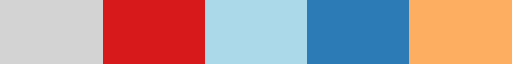

under

bad

over

```python
from matplotlib.colors import ListedColormap

# LISA colors
lc = {
    "ns": "lightgrey",  # Values of 0
    "HH": "#d7191c",  # Values of 1
    "LH": "#abd9e9",  # Values of 2
    "LL": "#2c7bb6",  # Values of 3
    "HL": "#fdae61",  # Values of 4
}
lisa_cmap = ListedColormap(
    [lc["ns"], lc["HH"], lc["LH"], lc["LL"], lc["HL"]]
)
lisa_cmap
```

## Local statistics on surfaces

```python
f, axs = plt.subplots(1, 2, figsize=(11, 5.5))
# Select pixels that are not missing data
pop.where(pop != pop.rio.nodata).plot(
    ax=axs[0], add_colorbar=False
)
# Rescale to [0, 1] by dividing by 4 (maximum value in `lisa_da`)
(lisa_da.where(lisa_da != -200) / 4).plot(
    cmap=lisa_cmap, ax=axs[1], add_colorbar=False
)
titles = ["Population by pixel", "Population clusters"]
for i in range(2):
    axs[i].axis("equal")
    axs[i].set_axis_off()
    axs[i].set_title(titles[i])
    contextily.add_basemap(axs[i], crs=lisa_da.rio.crs)
```

[figure not shown]

## Local spatial autocorrelation

**Take-aways**

Local statistics are one of the most commonly used tools in the geographic data science toolkit — the most common **“first brush”** geographic statistic for many analyses.

- **Local Moran’s $I_i$** summarizes the *co-variation* between observations and their immediate surroundings $\rightarrow$ cluster **and** outlier status
- **Getis-Ord local $G$** compares the *sum of values* in the area around each site $\rightarrow$ hotspot / coldspot, but no outliers

Used properly, local statistics provide a powerful way to analyze and visualize the structure of geographic data.

# Point Pattern Analysis

## Point pattern analysis

**Two ways to understand points**

**1. Fixed objects in space** - location is taken as given (*exogenous*), secondary to the value observed at the point.

*Example:* the number of cars traversing a road intersection. The location is fixed; the data of interest is the measurement there. Analysis resembles that of polygons and lines.

**2. Sites of measurement from an underlying continuous process** - the measurement *could* theoretically take place anywhere, but was only carried out in certain locations.

*Example:* the length of birds’ wings. Location reflects bird movement and foraging; wing length reflects an ecological process.

**We will adopt the second perspective**: both the location and the measurement matter.

## Point pattern analysis

**What is a point pattern?**

When points are seen as **events** that could take place in several locations but only happen in a few of them, a collection of such events is a **point pattern**. The *location of points* is one of the key aspects of interest.

A good example is **geo-tagged photographs**: they could technically happen in many locations, but tend to concentrate in a handful.

Types:

- **unmarked** - only the coordinates of where the event occurred
- **marked** - more attributes are provided with the location (time, camera model, an “image quality score”)

## Point pattern analysis

**The questions**

Point pattern analysis is concerned with the **visualization, description, statistical characterization, and modeling** of point patterns:

- *What does the pattern look like?*
- *What is the nature of the distribution of points?*
- *Is there any structure in the way locations are arranged over space - are events clustered, or dispersed?*
- *Why do events occur in those places and not in others?*

## Point pattern analysis

**Process vs. pattern**

**Process** - the underlying mechanism at work that generates the outcome. Abstract; we do not get to see it. It is the *how*.

**Pattern** - the *result* of that process. Often the only trace we can observe, and thus the only input we have to reconstruct it.

> Pattern is only a reflection of process. The real challenge is not to characterize the former but to use it to work out the latter.

## Patterns in Tokyo photographs

```python
from sklearn.cluster import DBSCAN
```

**Flickr metadata**

Geo-referenced images uploaded to Flickr, extracted from the 100m Flickr dataset — a form of **volunteered geographic information (VGI)**.

```python
db = pandas.read_csv(f"{GDS}/tokyo/tokyo_clean.csv")
db.info()
```

```
<class 'pandas.DataFrame'>
RangeIndex: 10000 entries, 0 to 9999
Data columns (total 7 columns):
 #   Column                Non-Null Count  Dtype
---  ------                --------------  -----
 0   user_id               10000 non-null  str
 1   longitude             10000 non-null  float64
 2   latitude              10000 non-null  float64
 3   date_taken            10000 non-null  str
 4   photo/video_page_url  10000 non-null  str
 5   x                     10000 non-null  float64
 6   y                     10000 non-null  float64
dtypes: float64(4), str(3)
memory usage: 1.4 MB
```

10,000 photographs: user ID, latitude/longitude, a Pseudo-Mercator version (`x`, `y`), the timestamp, and the URL.

Note the spatial information is encoded as **separate columns** - in contrast to previous slides where it lived in a single geometry column.

## Point pattern analysis

**Showing patterns as dots on a map**

```python
seaborn.jointplot(x="longitude", y="latitude", data=db, s=0.5);
```

[figure not shown]

A good start - dots concentrate in the centre in a non-random pattern, with more localized clusters within. But **two key drawbacks**: it lacks geographical context, and in dense areas the points become an indistinct blur.

## Point pattern analysis

**Adding context**

```python
joint_axes = seaborn.jointplot(
    x="longitude", y="latitude", data=db, s=0.5
)
contextily.add_basemap(
    joint_axes.ax_joint,
    crs="EPSG:4326",
    source=BASEMAP_NOLABELS,
);
```

[figure not shown]

We pull out the axis where the points are plotted and add the basemap there, specifying the CRS as **WGS84** since we are plotting longitude and latitude.

## Point pattern analysis

**From tables to surfaces, again: showing density with hexbinning**

The second problem is **cluttering**. Where too many photos concentrate, opaque dots on top of one another obscure the pattern.

The solution is moving from *tables to surfaces* — recast here as a **spatial (two-dimensional) histogram**:

1. generate a regular grid (squared or hexagonal)
2. count how many dots fall within each grid cell
3. present it as any other choropleth

We use **hexagonal** binning: less shape distortion and more regular connectivity between cells than a squared grid.

```python
f, ax = plt.subplots(1, figsize=(9, 7))
# 50 hexagons in each dimension, no borderlines,
# half transparency, reverse viridis colormap
hb = ax.hexbin(
    db["x"],
    db["y"],
    gridsize=50,
    linewidths=0,
    alpha=0.5,
    cmap="viridis_r",
)
contextily.add_basemap(
    ax, source=BASEMAP
)
plt.colorbar(hb)
ax.set_axis_off()
```

[figure not shown]

A lot more detail: the majority of photographs relate to much more **localized** areas than the previous map suggested.

## Kernel density estimation

**Escaping the grid**

Grids are the spatial equivalent of a histogram: the user decides how many “buckets” and points are counted discretely. Fast, efficient, potentially detailed — but a **discretization of an essentially contiguous phenomenon**, which may introduce distortions (e.g., the *modifiable areal unit problem*).

A **kernel density estimate (KDE)** is an empirical approximation of the probability density function:

- lay a grid of **points** over the space of interest
- place **kernel functions** on them that count nearby points with a weight based on distance
- aggregate to generate a global probability surface

The most common kernel is the **Gaussian** one.

```python
from pointpats import plot_density

f, ax = plt.subplots(1, figsize=(8, 8))
seaborn.scatterplot(x="x", y="y", data=db, s=0.5, ax=ax)
plot_density(
    data=db[["x", "y"]].values,
    bandwidth=1000,
    cmap="viridis_r",
    ax=ax,
)
contextily.add_basemap(
    ax, source=BASEMAP
)
ax.set_axis_off()
```

[figure not shown]

A **smoother** output capturing the same structure as the hexbin, but easing the transitions between areas.

## Centrography

**The point pattern’s measures of central tendency**

Centrography is the analysis of **centrality** in a point pattern: the general **location** and **dispersion** of the pattern.

If the hexbin is a “spatial histogram”, centrography is the point pattern equivalent of the **mean** and **standard deviation**.

Many indices provide an indication of:

- **where** a point pattern is
- how **tightly** it clusters around its centre
- how **irregular** its shape is

## Tendency

**Mean and median centres**

- **centre of mass** — for marked patterns, a central point close to observations with higher marked values; for unmarked patterns it equals the **mean centre**, the average of the coordinates
- **median centre** — half the data is above or below, and half to its left or right

```python
from pointpats import centrography

mean_center = centrography.mean_center(db[["x", "y"]])
med_center = centrography.euclidean_median(db[["x", "y"]])
print("mean  :", mean_center)
print("median:", med_center)
```

```
mean  : [15555485.40274061  4255558.40964842]
median: [15556147.99665746  4255894.38009221]
```

```python
joint_axes = seaborn.jointplot(
    x="x", y="y", data=db, s=0.75, height=7
)
joint_axes.ax_joint.scatter(
    *mean_center, color="red", marker="x", s=50, label="Mean Center"
)
joint_axes.ax_marg_x.axvline(mean_center[0], color="red")
joint_axes.ax_marg_y.axhline(mean_center[1], color="red")
joint_axes.ax_joint.scatter(
    *med_center,
    color="limegreen",
    marker="o",
    s=50,
    label="Median Center"
)
joint_axes.ax_marg_x.axvline(med_center[0], color="limegreen")
joint_axes.ax_marg_y.axhline(med_center[1], color="limegreen")
joint_axes.ax_joint.legend()
contextily.add_basemap(
    joint_axes.ax_joint, source=BASEMAP
)
joint_axes.ax_joint.set_axis_off()
plt.show()
```

[figure not shown]

The discrepancy is caused by **skew**: far-out clusters in West and South Tokyo pull the *mean* centre away from the *median* one.

## Dispersion

**Standard distance**

The average distance away from the centre of the point cloud:

```python
centrography.std_distance(db[["x", "y"]])
```

```
np.float64(8778.218559042176)
```

On average, pictures are taken around **8,800 metres** from the mean centre.

**The standard deviational ellipse**

An ellipse drawn from the data reflecting its **centre**, **dispersion**, and **orientation**:

```python
major, minor, rotation = centrography.ellipse(db[["x", "y"]])
print(major, minor, rotation)
```

```
9526.805378580619 7961.4728871384605 0.3904980332553666
```

```python
from matplotlib.patches import Ellipse

f, ax = plt.subplots(1, figsize=(8, 8))
ax.scatter(db["x"], db["y"], s=0.75)
ax.scatter(
    *mean_center, color="red", marker="x", label="Mean Center"
)
ax.scatter(
    *med_center, color="limegreen", marker="o", label="Median Center"
)
ellipse = Ellipse(
    xy=mean_center,  # center the ellipse on our mean center
    width=major * 2,  # ellipse() only gives half the axis
    height=minor * 2,
    angle=numpy.rad2deg(rotation),  # degrees, not radians
    facecolor="none",
    edgecolor="red",
    linestyle="--",
    label="Std. Ellipse",
)
ax.add_patch(ellipse)
ax.legend()
contextily.add_basemap(
    ax, source=BASEMAP
)
plt.show()
```

[figure not shown]

## Extent

**Five shapes, varying tightness**

- **convex hull** — the tightest *convex* shape enclosing the points; never “doubles back”, no divets, valleys or holes; all interior angles below 180°
- **alpha shape** (concave hull) — a *tighter* version of the convex hull
- **minimum bounding rectangle** — the tightest axis-aligned rectangle
- **minimum rotated rectangle** — allowing diagonals gives a smaller area, but an askew rectangle
- **minimum bounding circle** — the smallest enclosing circle; often bigger than the bounding rectangle

To make differences clear we use the photos of the **most prolific user** in the dataset.

## Extent

**The rolling-ball intuition**

A convex hull is the space left over when rolling a **really large** ball around the shape — so large its radius is infinite, so the lines are straight.

An **alpha shape** is the space made from rolling a **small** ball around the shape. It rolls into the dips and valleys between points. As the ball grows, the alpha shape becomes the convex hull. If alpha gets *too* small, the ball “slips” through the points, producing **more than one hull**.

```python
import libpysal

user = db.query('user_id == "95795770@N00"')
coordinates = user[["x", "y"]].values

convex_hull_vertices = centrography.hull(coordinates)
alpha_shape, alpha, circs = libpysal.cg.alpha_shape_auto(
    coordinates, return_circles=True
)
print("n points:", len(coordinates), "| alpha:", round(alpha, 1))
```

```
n points: 419 | alpha: 8652.5
```

`alpha_shape_auto` finds the smallest *single* alpha shape, so you do not have to guess how big the ball needs to be.

**The three remaining bounds**

```python
# Minimum rotated rectangle, via geopandas
point_array = geopandas.points_from_xy(x=user.x, y=user.y)
min_rot_rect = point_array.union_all().minimum_rotated_rectangle

# Axis-aligned minimum bounding rectangle, via pointpats
min_rect_vertices = centrography.minimum_bounding_rectangle(
    coordinates
)

# Minimum bounding circle
(center_x, center_y), radius = centrography.minimum_bounding_circle(
    coordinates
)
print("circle radius:", round(radius, 1))
```

```
circle radius: 19287.1
```

## Extent

```python
from matplotlib.patches import Polygon, Circle, Rectangle

convex_hull_patch = Polygon(
    convex_hull_vertices,
    closed=True,
    edgecolor="blue",
    facecolor="none",
    linestyle=":",
    linewidth=2,
    label="Convex Hull",
)
min_rect_width = min_rect_vertices[2] - min_rect_vertices[0]
min_rect_height = min_rect_vertices[3] - min_rect_vertices[1]
min_rect_patch = Rectangle(
    min_rect_vertices[0:2],
    width=min_rect_width,
    height=min_rect_height,
    edgecolor="goldenrod",
    facecolor="none",
    linestyle="dashed",
    linewidth=2,
    label="Min Bounding Rectangle",
)
circ_patch = Circle(
    (center_x, center_y),
    radius=radius,
    edgecolor="red",
    facecolor="none",
    linewidth=2,
    label="Min Bounding Circle",
)

f, ax = plt.subplots(1, figsize=(9, 9))
geopandas.GeoSeries([alpha_shape]).plot(
    ax=ax,
    edgecolor="purple",
    facecolor="none",
    linewidth=2,
    label="Alpha Shape",
)
geopandas.GeoSeries([min_rot_rect]).plot(
    ax=ax,
    edgecolor="green",
    facecolor="none",
    linestyle="--",
    label="Min Rotated Rectangle",
    linewidth=2,
)
ax.add_patch(convex_hull_patch)
ax.add_patch(min_rect_patch)
ax.add_patch(circ_patch)
ax.scatter(db.x, db.y, s=0.75, color="grey")
ax.scatter(user.x, user.y, s=100, color="r", marker="x")
ax.legend(ncol=1, loc="center left")
contextily.add_basemap(
    ax, source=BASEMAP
)
plt.show()
```

[figure not shown]

The **alpha shape** is much tighter than the rest. The bounding rectangle and circle are the **loosest** - they contain the most area outside the user’s typical range - but they are the simplest shapes to draw and understand.

## Randomness and clustering

**How *even* is the distribution?**

Do points tend to all cluster near one another, or disperse evenly throughout the problem area? This refers to the **intensity** or **dispersion** of the pattern overall.

In other words: **what is the overall degree of clustering?**

Two families of technique:

1. **Quadrat statistics** - split the data into small areas (“buckets”) and examine the **uniformity of counts** across them
2. **Ripley’s functions** - measurements of the **distance between points** in the pattern

## Randomness and clustering

**A known-random benchmark**

It helps to have a pattern from a known **completely spatially random** process: the location and number of points is totally random, with neither clustering nor dispersion. This is a **Poisson point process**.

```python
from pointpats import (
    distance_statistics,
    QStatistic,
    random,
    PointPattern,
)

random_pattern = random.poisson(
    coordinates, size=len(coordinates)
)
```

By default the simulator works with the **bounding box** of the input pattern. To restrict it to a tighter area, pass a hull:

```python
random_pattern_ashape = random.poisson(
    alpha_shape, size=len(coordinates)
)
```

```python
f, axs = plt.subplots(1, 2, figsize=(11, 5.5))
for ax, rp, title in [
    (axs[0], random_pattern, "Random in bounding box"),
    (axs[1], random_pattern_ashape, "Random in alpha shape"),
]:
    ax.scatter(
        *coordinates.T, color="k", marker=".", label="Observed"
    )
    ax.scatter(*rp.T, color="r", marker="x", label="Random")
    contextily.add_basemap(
        ax, source=BASEMAP
    )
    ax.set_title(title)
    ax.set_axis_off()
axs[0].legend(ncol=1, loc="center left")
plt.show()
```

[figure not shown]

## Quadrat statistics

**Counting in cells**

Examine the spatial distribution in terms of the count of observations falling within each cell, testing whether observations are spread **evenly**.

Strictly speaking, quadrat statistics examine the *evenness* of the distribution using a $\chi^2$ test common in the analysis of contingency tables.

```python
qstat = QStatistic(coordinates)
qstat.plot()
```

[figure not shown]

With the default three-by-three grid, the central square has over 350 observations while surrounding cells have far fewer.

## Quadrat statistics

**Observed vs. random**

```python
qstat.chi2_pvalue
```

```
np.float64(0.0)
```

In contrast, the totally random pattern has nearly the same count in every cell:

```python
qstat_null = QStatistic(random_pattern)
qstat_null.plot()
```

[figure not shown]

```python
qstat_null.chi2_pvalue
```

```
np.float64(0.6258543046968585)
```

## Quadrat statistics

**A trap: irregular study areas**

Quadrat counts are measured on a **regular tiling** overlaid on a potentially **irregular** extent. Irregular *but random* patterns can be mistakenly found “significant”.

```python
qstat_null_ashape = QStatistic(random_pattern_ashape)
qstat_null_ashape.plot()
```

[figure not shown]

```python
qstat_null_ashape.chi2_pvalue
```

```
np.float64(2.8424411001680185e-26)
```

The test finds this **statistically non-random** - yet our simulating process guaranteed that *within the given study area* it is completely spatially random.

One way to reconcile this: think of the quadrat statistic as testing both the **uniformity of points** *and* the **shape of their extent**. Useful sometimes; use with caution.

## Ripley’s alphabet of functions

**Two quantities**

Derived from Ripley’s seminal work on characterizing clustering or co-location:

- **nearest neighbour distances** - how far each point is from its closest companion
- **“gaps”** in the pattern - how far empty space is from the nearest point

Each function characterizes an aspect of the pattern **as we increase the distance range** from each point.

**Ripley’s $G$**

Keeps track of the **proportion of points for which the nearest neighbour is within a given distance threshold**, plotted against increasing distance radii.

- $G$ increasing **rapidly** with distance $\rightarrow$ **clustered**
- $G$ increasing **slowly** $\rightarrow$ **dispersed**
- something in between $\rightarrow$ hard to distinguish from pure chance

## Ripley’s alphabet of functions

```python
f, ax = plt.subplots(1, 2, figsize=(8, 4), sharex=True, sharey=True)
ax[0].scatter(*random_pattern.T, color="red")
ax[1].scatter(
    *random_pattern.T,
    color="red",
    zorder=100,
    marker=".",
    label="Points"
)
nn_ixs, nn_ds = PointPattern(random_pattern).knn(1)
for coord, nn_ix, nn_d in zip(random_pattern, nn_ixs, nn_ds):
    dx, dy = random_pattern[nn_ix].squeeze() - coord
    ax[1].arrow(
        *coord,
        dx,
        dy,
        length_includes_head=True,
        overhang=0,
        head_length=300 * 3,
        head_width=300 * 3,
        width=50 * 3,
        linewidth=0,
        facecolor="k",
        head_starts_at_zero=False
    )
ax[0].axis([1.554e7, 1.556e7, 4240000, 4260000])
for a in ax:
    a.set_xticks([])
    a.set_yticks([])
f.tight_layout()
plt.show()
```

[figure not shown]

Black arrows point to each point’s **nearest neighbour**. Note some pairs are *mutual* nearest neighbours (arrows both ways), others are not.

## Ripley’s $G$

**Comparing against simulated randomness**

`g_test` computes the $G$ function for the empirical data *and* hypothetical replications under a completely spatially random process.

```python
g_test = distance_statistics.g_test(
    coordinates, support=40, keep_simulations=True
)
```

```python
f, ax = plt.subplots(
    1, 2, figsize=(9, 3), gridspec_kw=dict(width_ratios=(6, 3))
)
# plot all the simulations with very fine lines
ax[0].plot(
    g_test.support, g_test.simulations.T, color="k", alpha=0.01
)
ax[0].plot(
    g_test.support,
    numpy.median(g_test.simulations, axis=0),
    color="cyan",
    label="median simulation",
)
ax[0].plot(
    g_test.support, g_test.statistic, label="observed", color="red"
)
ax[0].set_xlabel("distance")
ax[0].set_ylabel("% of nearest neighbor\ndistances shorter")
ax[0].legend()
ax[0].set_xlim(0, 2000)
ax[0].set_title(r"Ripley's $G(d)$ function")
ax[1].scatter(*coordinates.T)
ax[1].set_xticks([])
ax[1].set_yticks([])
ax[1].set_title("Pattern")
f.tight_layout()
plt.show()
```

[figure not shown]

The red empirical function rises **much faster** than simulated random patterns $\rightarrow$ points are *closer* to their nearest neighbours than expected. The pattern is **clustered**.

## Ripley’s $F$

**The “empty space function”**

Where $G$ analyses the distance **between** points in the pattern, $F$ analyses the distance **to** points in the pattern **from locations in empty space**.

$F$ accumulates, for a growing distance range, the percentage of points found within that range from a *random* point pattern generated within the extent of the observed one.

- large gaps or empty areas $\rightarrow$ $F$ increases **slowly**
- highly dispersed pattern $\rightarrow$ $F$ increases **rapidly**

```python
f_test = distance_statistics.f_test(
    coordinates, support=40, keep_simulations=True
)
```

```python
f, ax = plt.subplots(
    1, 2, figsize=(9, 3), gridspec_kw=dict(width_ratios=(6, 3))
)
ax[0].plot(
    f_test.support, f_test.simulations.T, color="k", alpha=0.01
)
ax[0].plot(
    f_test.support,
    numpy.median(f_test.simulations, axis=0),
    color="cyan",
    label="median simulation",
)
ax[0].plot(
    f_test.support, f_test.statistic, label="observed", color="red"
)
ax[0].set_xlabel("distance")
ax[0].set_ylabel("% of nearest point in pattern\ndistances shorter")
ax[0].legend()
ax[0].set_xlim(0, 2000)
ax[0].set_title(r"Ripley's $F(d)$ function")
ax[1].scatter(*coordinates.T)
ax[1].set_xticks([])
ax[1].set_yticks([])
ax[1].set_title("Pattern")
f.tight_layout()
plt.show()
```

[figure not shown]

The observed $F$ increases **much more slowly** than the simulations $\rightarrow$ many gaps in our pattern $\rightarrow$ **clustered**.

## Identifying clusters

**Cluster*ing* vs. cluster*s***

The previous sections characterize whether a pattern is dispersed or clustered - the degree of overall **clustering**.

But knowing a pattern is clustered does not tell us **where** the clusters are. For that we need a method able to identify **areas of high density of points**.

The distinction is exactly analogous to global vs. local spatial autocorrelation.

The difference in technique comes from the unique nature of points: earlier methods take the **location of objects as given** and study the configuration of *values*; point pattern methods treat points as **events that happen in particular locations but could happen in a much broader set of places**.

## DBSCAN

**Density-Based Spatial Clustering of Applications with Noise**

A widely used algorithm from knowledge discovery and machine learning. Its popularity resides in **intellectual simplicity** and **computational tractability**.

In some ways a point pattern counterpart of the local statistics - but with a fundamental difference: **DBSCAN is not based on an inferential framework**, it is a **deterministic algorithm**. We cannot estimate the degree to which the clusters found are compatible with spatial randomness.

## DBSCAN

**The definition**

A **cluster** is a concentration of at least `m` points, each within a distance `r` of at least another point in the cluster. Each point is classified as:

- **Noise** - outside a cluster
- **Core** - inside a cluster, with at least `m` points of the cluster within distance `r`
- **Border** - inside a cluster, with *fewer* than `m` points of the cluster within `r`

Both `m` and `r` must be specified **by the user** - the flexibility *and* the limitation.

## DBSCAN

**A first run with the defaults**

```python
# Define DBSCAN
clusterer = DBSCAN()
# Fit to our data
clusterer.fit(db[["x", "y"]])
```

```
DBSCAN()
```

Following the standard scikit-learn interface: **define**, then **fit**.

```python
# Indices of points classified as *cores*
clusterer.core_sample_indices_[:5]
```

```
array([ 1, 22, 30, 36, 42])
```

```python
# Cluster membership; -1 means *noise*
clusterer.labels_[:5]
```

```
array([-1,  0, -1, -1, -1])
```

`labels_` always has the same length as the number of points.

```python
lbls = pandas.Series(clusterer.labels_, index=db.index)
f, ax = plt.subplots(1, figsize=(8, 8))
# Subset points that are not part of any cluster (noise)
noise = db.loc[lbls == -1, ["x", "y"]]
ax.scatter(noise["x"], noise["y"], c="grey", s=5, linewidth=0)
ax.scatter(
    db.loc[db.index.difference(noise.index), "x"],
    db.loc[db.index.difference(noise.index), "y"],
    c="red",
    linewidth=0,
)
contextily.add_basemap(
    ax, source=BASEMAP
)
ax.set_axis_off()
plt.show()
```

[figure not shown]

Not satisfactory - *way* too many points classified as noise. The defaults are a radius of **0.5** and a minimum of **five** points. Since our data is in metres, half a metre picks up only hyper-local clusters.

## DBSCAN

**Sensible parameters**

Let a cluster need at least roughly **1% of all points**, and expand the radius to **500 metres**:

```python
minp = numpy.round(db.shape[0] * 0.01)
minp
```

```
np.float64(100.0)
```

```python
clusterer = DBSCAN(eps=500, min_samples=int(minp))
clusterer.fit(db[["x", "y"]])
lbls = pandas.Series(clusterer.labels_, index=db.index)
lbls.value_counts().head()
```

```
-1     4888
 1     1205
 6      585
 10     493
 0      475
Name: count, dtype: int64
```

```python
f, ax = plt.subplots(1, figsize=(8, 8))
noise = db.loc[lbls == -1, ["x", "y"]]
ax.scatter(noise["x"], noise["y"], c="grey", s=5, linewidth=0)
ax.scatter(
    db.loc[db.index.difference(noise.index), "x"],
    db.loc[db.index.difference(noise.index), "y"],
    c="red",
    linewidth=0,
)
contextily.add_basemap(
    ax, source=BASEMAP
)
ax.set_axis_off()
plt.show()
```

[figure not shown]

Now the algorithm picks up the **general patterns**: the main concentrations of photographic attention in Tokyo.

## Point pattern analysis

**Take-aways**

1. **Visualize** the locations, overcoming the “cluttering” challenge - hexbin and KDE
2. **Characterize** their spatial distribution statistically - central tendency, dispersion, extent; the point pattern counterparts of the mean and standard deviation
3. **Test** whether the pattern is clustered or dispersed - quadrat and Ripley’s functions
4. **Locate** the clusters themselves - DBSCAN

These techniques answer fundamental questions about point patterns representing widely varied phenomena: from where photographs were taken, to the distribution of bird nests, to the clustering of bike crashes in a city.

## Exercises

**Choropleths**

1. A variable such as population density can be very **skewed**. What is an appropriate choropleth classification for a skewed variable?
2. Provide two solutions to the problem of **ties** when applying quantile classification to $y=[2,2,2,2,2,2,4,7,8,9,20,21]$ with $k=4$. Discuss the merits of each.
3. Which classifiers are appropriate for data with high **multi-modality**? Are there colormaps that work well for multi-modal data?
4. Contrast classed and class-less (continuous-scale) choropleths. Strengths and limitations of each?
5. To what extent do common classifiers take the **geographical** distribution into consideration? Can you think of ways to incorporate it?
6. The Fisher-Jenks classifier always has more internally homogeneous classes. Given this, why might one choose a different $k$-classifier?

## Exercises

**Global autocorrelation**

1. Pull `Pct_Rejected` out of `ref`. Map it, build an 8-nearest-neighbour $W$, make a Moran scatterplot, and compute Moran’s $I$. What do we learn about the geography of vote rejection?
2. Imagine the referendum required **60%** to succeed. Create a binary variable from `Pct_Leave` on that threshold, map it, and recompute the join counts. What changes?
3. Build `wk4` and `wk12` KNN weights. Map the spatial lag of `Pct_Leave` under each; regenerate the Moran scatterplots; recompute Moran’s $I$. How and why do they differ? Generalize: what is the effect of a more **densely connected** graph?
4. Compute Moran’s $I$, Geary’s $C$ and Getis-Ord’s $G$ for `Pct_Rejected` with the same $W$. Do you draw substantially different conclusions? Can you find cases where $I$ and $G$ **disagree substantially**? What would drive that?
5. Using KNN weights, find the $k$ at which Moran’s $I$ is largest. Plot $I$ against $k$.

## Exercises

**Local autocorrelation**

1. Repeat the Local Moran and Getis-Ord analyses for `Pct_Turnout`. Is there a geography to how involved people were?
2. **Rates.** Local Moran statistics rest on distributional assumptions, and *rate* data embeds the relationship between an event and a population. Build a table with `Electorate`, `Votes_Cast` and `Leave`; scatterplot each against percent Leave; confirm with `scipy.stats.kendalltau`. Then use `esda.moran.Moran_Rate` and `Moran_Local_Rate` and compare against the uncorrected estimates — do any sites change their significance classification? Use `pandas.crosstab`.
3. **Permutation distributions.** The per-observation shuffle distributions live in `.rlisas`. Plot the distribution for the first and last observation, with `plt.axvline()` at the observed value. From the distributions alone, do you expect either to be significant?
4. **Uncertainty.** Map the standard errors in `.seI_sim`. Are some areas more uncertain? Verify that the standard deviation of each `.rlisas` row equals its `seI_sim`.
5. Scatterplot `go_i.Zs` against `go_i_star.Zs`. Then scatterplot percent Leave against their *difference*. Is there a relationship?

## Exercises

**Point patterns**

1. What is the trade-off when picking the hexagon granularity in hexbinning? Can we pick a “good” number of bins for all problems?
2. KDE avoids partitioning space into buckets — but what are its limitations? Reproduce the KDE map varying the kernel and the bandwidth. What happens when the bandwidth is very small? How does that relate to the number of hexbins?
3. What characteristics would a point pattern need for the **mean and median centres to coincide**?
4. Using `libpysal.cg.alpha_shape`, plot the alpha hull for $\alpha = 0, .2, .4, .6, .8, 1, 1.5, 2, 4$. What happens as alpha increases?
5. Compute the **density** of photographs using each extent definition (bounding circle, bounding rectangle, rotated rectangle, convex hull, alpha shape). How much does the choice matter?
6. How does the density of quadrats affect quadrat statistics?
7. Can you use Ripley’s functions to inform the choice of **DBSCAN parameters**? How?